# R Notebook

# Box plots and applied plotting

Author: Jiesheng Zheng

Box plots are usually used in statistical analysis. There were two papers in [Nature Method](https://www.nature.com/articles/nmeth.2811) published in 2014 depicting the benefits of box plots and an online ploting tool. The several important terms in box plot are **Min**, **Q1**, **Median**, **Q3**, and **Max**, Here I provide a [video](https://www.coursera.org/lecture/basic-statistics/1-05-range-interquartile-range-and-box-plot-RbWIZ)which help you better understand these concepts.

Now I will give you a specific example. Here is a matrix of genes expression. The first column is gene name and the rest columns are cell samples names.

```r
profile="Name;2cell_1;2cell_2;2cell_3;4cell_1;4cell_2;4cell_3;zygote_1;zygote_2;zygote_3
A;4;6;7;3.2;5.2;5.6;2;4;3
B;6;8;9;5.2;7.2;7.6;4;6;5
C;8;10;11;7.2;9.2;9.6;6;8;7
D;10;12;13;9.2;11.2;11.6;8;10;9
E;12;14;15;11.2;13.2;13.6;10;12;11
F;14;16;17;13.2;15.2;15.6;12;14;13
G;15;17;18;14.2;16.2;16.6;13;15;14
H;16;18;19;15.2;17.2;17.6;14;16;15
I;17;19;20;16.2;18.2;18.6;15;17;16
J;18;20;21;17.2;19.2;19.6;16;18;17
L;19;21;22;18.2;20.2;20.6;17;19;18
M;20;22;23;19.2;21.2;21.6;18;20;19
N;21;23;24;20.2;22.2;22.6;19;21;20
O;22;24;25;21.2;23.2;23.6;20;22;21"
```

Deriving information from it is so hard for us. Therefore, we can use boxplots to better understand the dispersion of the data.

We can use **ggplot2** to draw box plots.

```r
# Load packages
install.packages("ggplot2")
install.packages("reshape2")
```

We should transfer our data into a vefsion which can be readed by ggplot2.

```r
profile_text <- read.table(text=profile, header=T, row.names=1, quote="",sep=";", check.names=F)
```

```r
data_m = melt(profile_text, id.vars=NULL)
head(data_m)
```

|  | variable | value |
| --- | --- | --- |
| 1 | 2cell_1 | 4 |
| 2 | 2cell_1 | 6 |
| 3 | 2cell_1 | 8 |
| 4 | 2cell_1 | 10 |
| 5 | 2cell_1 | 12 |
| 6 | 2cell_1 | 14 |

Now you can draw box plots.

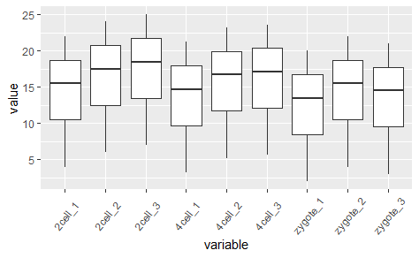

```r
# Draw the box plot
b = ggplot(data_m, aes(x=variable, y=value)) + geom_boxplot() +
theme(axis.text.x=element_text(angle=50,hjust=0.5, vjust=0.5))
b
```

You can also add some colours to beautify your plots. If you want to know each argument, please type *?ggplot* in Console.

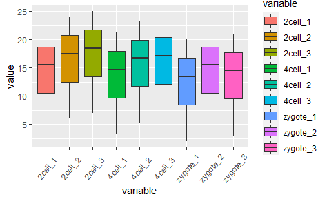

```r
b = ggplot(data_m, aes(x=variable, y=value,fill=variable)) +
geom_boxplot() +
theme(axis.text.x=element_text(angle=50,hjust=0.5, vjust=0.5))
b
```

Now there are some other plots which are quite similar to box plots. **Violin plots** is one you might want to know. Here I introduce [violin plots](https://www.youtube.com/watch?v=ktZH1OUvD4o).(you can lick to understand what is a violin plot) We can also use ggplot to draw violin plots.

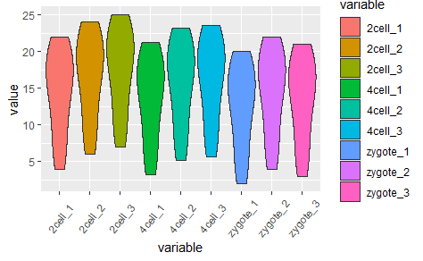

```r
# Draw violin plots
v = ggplot(data_m, aes(x=variable, y=value,fill=variable)) +
geom_violin() +
theme(axis.text.x=element_text(angle=50,hjust=0.5, vjust=0.5))
v
```

In addition, I want to introduce another plot which is called **Jitter plot**, which is a useful way of handling overplotting caused by discreteness in smaller datasets. Here we use **ggbeeswarm** to draw Jitter plots.

```r
# Load the package
install.packages("ggbeeswarm")
```

For better performance, I just keep only one sample data.*Grepel* is a Linux-like command allows you grep certain patterns.

```r
# Grep the certain pattern
data_m2 = data_m[grepl("_3", data_m$variable),]
```

Now we can draw the Jitter plot.

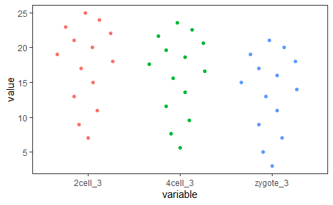

```r
J = ggplot(data_m2, aes(x=variable, y=value),color=variable) +
geom_quasirandom(aes(colour=factor(variable))) +
theme_bw() + theme(panel.grid.major = element_blank(),
panel.grid.minor = element_blank(), legend.key=element_blank()) +
theme(legend.position="none")
J
```